# HW12

Sean Fahey

2023-04-03

```r
knitr::opts_chunk$set(warning = FALSE, message = FALSE)
library(ggplot2)
library(boot)
library(tidyr)
```

# In-Class

```r
chimp = read.csv("ChimpBrains.csv", header=TRUE)
chimp$chimpName = as.factor(chimp$chimpName)
chimp$sex = as.factor(chimp$sex)

ragweed = read.csv("Ragweed.csv", header=TRUE)
ragweed$ID = as.factor(ragweed$ID)
ragweed$Site = as.factor(ragweed$Site)

summary(ragweed)
```

```
##        ID           Site      Biomass
##  1      :1   Protected:6   Min.   : 3.000
##  2      :1   Roadcut  :8   1st Qu.: 6.250
##  3      :1                 Median : 8.000
##  4      :1                 Mean   : 7.857
##  5      :1                 3rd Qu.: 9.750
##  6      :1                 Max.   :12.000
##  (Other):8
```

### Permutation analysis

In ragweed data set we have 2 groups and we want to decide if they’re different; “roadcut” and “protected” (Site).

Step 1, decide test statistic:

- |mean(Roadcut) - mean(Protected)| works well. We get 3.6 here.

Step 2, generate a null distribution:

- Figure out what it would look like if site type didn’t matter.
- We expect Null distribution to cluster around 0, but not be exactly 0.
- Randomly re-sample/shuffle the data into “roadcut” and “protected” (just shuffle the Biomass column basically). Calculate the difference using the formula from above.
- Re-do the shuffle, get another value. Do this until we have 10,000 values.
- This tells us what to expect if only sampling error causes the difference between groups.

Step 3, decide on a one tailed or two tailed test

- Do extremes only show up on one side? For this, yes.
- Figure out where the p=0.05 area falls. For one tailed test, this is the furthest right or left 5% of the area in a histogram. For a 2-tailed, this would be the furthest 2.5% on each side.
- Take the 10,000 values, put them in order, get the 95th percentile.

```r
ragmean = aggregate(Biomass~Site, data=ragweed, FUN = mean)
ragdiff = abs(ragmean$Biomass[1] - ragmean$Biomass[2])

print(ragmean)
```

```
##        Site  Biomass
## 1 Protected 5.833333
## 2   Roadcut 9.375000
```

```r
print(ragdiff)
```

```
## [1] 3.541667
```

```r
# vector is a data store similar to a column in a data frame. Preset length.
absdiffs = vector(mode='numeric', length=10000)
absdiffs[1] = ragdiff
```

```r
for (x in 1:10000) {
  # sample shuffles the selected column
  ragweed.shuffled = data.frame(
    Site=ragweed$Site,

    Biomass=sample(
      ragweed$Biomass,
      size=nrow(ragweed),
      replace=FALSE,
      )
    )

  ragmean = aggregate(
    Biomass~Site,
    data=ragweed.shuffled,
    FUN = mean,
    )

  ragdiff.shuffled = abs(ragmean$Biomass[1] - ragmean$Biomass[2])

  absdiffs[x] = ragdiff.shuffled
}

mean(absdiffs)
```

```
## [1] 1.1153
```

```r
ragdiff
```

```
## [1] 3.541667
```

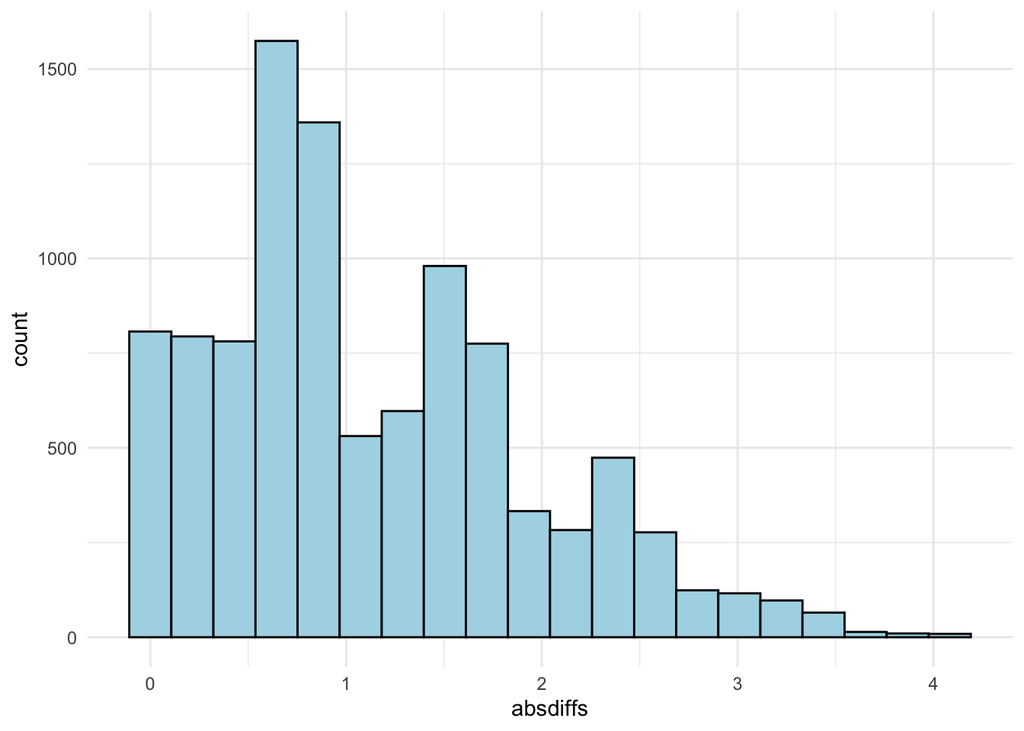

```r
plot = ggplot(
  ) +
  aes(
    absdiffs
  ) +
  geom_histogram(
    bins=20,
    colour="black",
    fill="lightblue",
  ) +
  theme_minimal()

plot
```

```r
absdiffs.sorted = sort(absdiffs)
absdiffs.sorted[9501]
```

```
## [1] 2.666667
```

Our value is 3.6, the point just past the 95th percentile is 2.667 in the run I did. So our p-value is going to be under 0.05.

```r
# sums the true/false values of the statement. True = 1, False = 0
sum(absdiffs >= ragdiff)
```

```
## [1] 71
```

```r
sum(absdiffs < ragdiff)
```

```
## [1] 9929
```

### Bootstrapping

Chimp data set has the asymmetry score of brain masses from each hemisphere of the brain. Basically, is there more thinkin’ stuff on the left side or the right side.

Bootstrap:

- Take a random sample **with replacement**
- Calculate the median of the new sample
- Calculate standard error

```r
asymmetry.median = median(chimp$asymmetryScore)
chimp.medians = vector(mode='numeric', length=10000)
chimp.medians[1] = asymmetry.median

asymmetry.median
```

```
## [1] 0.14
```

```r
for (x in 2:10000) {
  chimp.sample = sample(chimp$asymmetryScore, size=nrow(chimp), replace=TRUE)
  chimp.medians[x] = chimp.sample
}
```

```r
asymmetry.median
```

```
## [1] 0.14
```

```r
mean(chimp.medians)
```

```
## [1] 0.19531
```

```r
median(chimp.medians)
```

```
## [1] 0.12
```

```r
chimp.medians.sorted = sort(chimp.medians)
chimp.medians.sorted[250] # lower 95% confidence interval
```

```
## [1] -0.3
```

```r
chimp.medians.sorted[9750] # upper 95% confidence interval
```

```
## [1] 1.19
```

```r
bootstrap_function = function(x,i) {
  sample = x[i]

  sample_median = median(sample)
  sample_variance = var(sample)

  return(c(sample_median, sample_variance))
}
```

```r
chimp.bootstrap = boot(
  data = chimp$asymmetryScore,
  statistic = bootstrap_function,
  R = 9999, # number of re-samples
  )
chimp.bootstrap
```

```
##
## ORDINARY NONPARAMETRIC BOOTSTRAP
##
##
## Call:
## boot(data = chimp$asymmetryScore, statistic = bootstrap_function,
##     R = 9999)
##
##
## Bootstrap Statistics :
##      original       bias    std. error
## t1* 0.1400000  0.001984698  0.08626029
## t2* 0.1772239 -0.008444917  0.06172668
```

t1 and t2 are the two outputs the function gave.

```r
# boot.ci uses the bootstrap values to get a confidence interval.
chimp.bootstrap.ci = boot.ci(chimp.bootstrap, conf = 0.95)
chimp.bootstrap.ci
```

```
## BOOTSTRAP CONFIDENCE INTERVAL CALCULATIONS
## Based on 9999 bootstrap replicates
##
## CALL :
## boot.ci(boot.out = chimp.bootstrap, conf = 0.95)
##
## Intervals :
## Level      Normal              Basic             Studentized
## 95%   (-0.0311,  0.3071 )   (-0.0300,  0.3550 )   (-0.0281,  0.3932 )
##
## Level     Percentile            BCa
## 95%   (-0.075,  0.310 )   (-0.160,  0.300 )
## Calculations and Intervals on Original Scale
```

95% confidence intervals for Normal, Basic, Studentized, Percentile, and BCa. Each is a bit different. Percentile is like how we did it by hand (sort and index the value we want). BCa (Bias Corrected accelerated) is what people usually publish.

# Homework

### Task 1

- Using only the data for the ‘hot’ temperature treatment, compare the shell growth of the Crab and No-Crab treatment levels, using a permutation routine.
- Your code should load the data, carry out 9999 permutations (+1 original value), calculate the permuted difference in medians, and 95% confidence interval derived from the permuted differences.
- Is the observed difference in median growth of the two groups significantly different than what we would expect by random chance (i.e. if the two groups weren’t different)? Write your answer in your .Rmd file.

```r
snail_clean = read.csv("SnailGrowth.csv", header=TRUE)
snail_clean = drop_na(snail_clean)
```

```r
snail = snail_clean[snail_clean$Temperature == "hot",]
head(snail)
```

```
##    Temperature    Crab ShellGrowth.mg DryTissueGrowth.mg
## 9          hot    crab         7.7275         -4.5775635
## 10         hot    crab         6.1820          0.8386332
## 11         hot    crab         3.0910         -0.4285134
## 12         hot    crab         7.7275         -3.5141835
## 13         hot no crab         9.2730         -2.8087602
## 14         hot no crab        85.0025         11.6964615
```

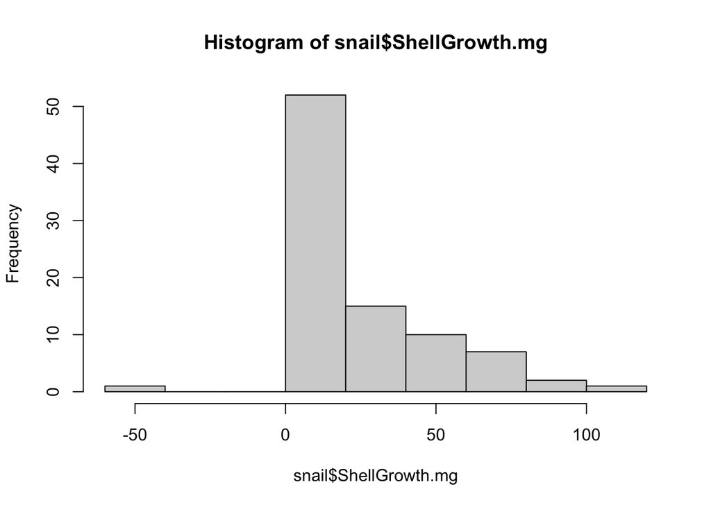

```r
hist(snail$ShellGrowth.mg)
```

This is skewed one direction, so we’ll use a one-tailed confidence interval. (Other than some weird outlier snail that lost it’s shell or something.)

```r
snailmedians = aggregate(
  ShellGrowth.mg~Crab,
  data=snail,
  FUN=median
  )

snailmedian.diff = abs(
  snailmedians$ShellGrowth.mg[1] -
  snailmedians$ShellGrowth.mg[2]
  )

snail.diffs = vector(mode='numeric', length=10000)
snail.diffs[1] = snailmedian.diff

snailmedian.diff
```

```
## [1] 13.9095
```

```r
for (x in 2:10000) {
  # sample shuffles the selected column
  snail.shuffled = data.frame(
    Crab=snail$Crab,

    ShellGrowth.mg=sample(
      snail$ShellGrowth.mg,
      size=nrow(snail),
      replace=FALSE,
      )
    )

  snailmedians.shuffled = aggregate(
    ShellGrowth.mg~Crab,
    data=snail.shuffled,
    FUN=median
  )

  snailmedian.diff.shuffled = abs(
    snailmedians.shuffled$ShellGrowth.mg[1] -
    snailmedians.shuffled$ShellGrowth.mg[2]
    )

  snail.diffs[x] = snailmedian.diff.shuffled
}
```

```r
# original difference median
snailmedian.diff
```

```
## [1] 13.9095
```

```r
# 95% confidence intervals
sort(snail.diffs)[9500] # one tail because of the plot above
```

```
## [1] 7.7275
```

The observed difference in median growth is significantly different than expected from random chance. Our 95% confidence interval (p=0.05) cuts off at 7.7275, but the median observed difference is 13.9095.

### Task 2

- Use the boot() and boot.ci() functions to estimate the mean shell growth and BCa 95% confidence intervals for the Ambient temperature, No-Crab treatment group, based on 9999 re-samples.
- Your code should print out the observed mean and BCa 95% confidence intervals

```r
snail = snail_clean[snail_clean$Temperature == "ambient",]
snail = snail[snail$Crab == "no crab",]

observed_mean = mean(snail$ShellGrowth.mg)
```

```r
bootstrap_function2 = function(x,i) {
  sample = x[i]
  sample_mean = mean(sample)

  return(sample_mean)
}
```

```r
snail.bootstrap = boot(
  data = snail$ShellGrowth.mg,
  statistic = bootstrap_function2,
  R = 9999, # number of resamples
  )
snail.bootstrap
```

```
##
## ORDINARY NONPARAMETRIC BOOTSTRAP
##
##
## Call:
## boot(data = snail$ShellGrowth.mg, statistic = bootstrap_function2,
##     R = 9999)
##
##
## Bootstrap Statistics :
##     original      bias    std. error
## t1* 65.02139 -0.03893393    5.019241
```

```r
print(observed_mean)
```

```
## [1] 65.02139
```

```r
snail.bootstrap.ci = boot.ci(snail.bootstrap, conf = 0.95, type='bca')
snail.bootstrap.ci
```

```
## BOOTSTRAP CONFIDENCE INTERVAL CALCULATIONS
## Based on 9999 bootstrap replicates
##
## CALL :
## boot.ci(boot.out = snail.bootstrap, conf = 0.95, type = "bca")
##
## Intervals :
## Level       BCa
## 95%   (55.86, 75.63 )
## Calculations and Intervals on Original Scale
```

This time we fall within the confidence interval. This is expected because we’re just running the bootstrap on a single group (ambient temp, no crab).